← Home

# Fertility

AIM: match the population data with the fertility rate, to be able to extrapolate for next years

The *fertility rate* ($fr$) is the average number of children per women, and has to be above 2 to keep the population stable.

ISTAT computes the fertility rate in `DCIS_FECONDITA1`, but I have to do some data reconcilation to make sure that I have a function I can use to compute newborns from the population data.

```python
import sys
from pathlib import Path
sys.path.insert(0, str(Path("../scripts").resolve()))

import numpy as np
import pandas as pd
import json
import matplotlib
import matplotlib.pyplot as plt
import plotly.express as px
import plotly.graph_objects as go
import plotly.io as pio
from plotly.subplots import make_subplots
from istat_source import worldbank_fertility
from copy import deepcopy
from istat_source import istat_data
import warnings

pio.renderers.default = 'plotly_mimetype+notebook'
pd.options.plotting.backend = "plotly"
warnings.filterwarnings("ignore", category=FutureWarning)

def get_colors(n, cmap_name="rainbow"):
    """Get colors for px colors_discrete argument, given the number of colors needed, n."""
    cmap = matplotlib.colormaps[cmap_name]
    colors = [cmap(i) for i in np.linspace(0, 1, n)]  # Generate colors
    colors_str = [f"rgba({int(color[0]*250)}, {int(color[1]*250)}, {int(color[2]*250)}, 1.0)" for color in colors]
    return colors_str
```

```python
dfp=pd.read_csv("../data/pop_by_age_year.csv", index_col=0).rename(columns=int)  # From Notebook#14
```

```python
df6 = istat_data(
    resource_id="25_326_DF_DCIS_FECONDITA1_5", key={"REF_AREA": "IT"}
).astype({"TIME_PERIOD": int})
df6
```

|  | FREQ | REF_AREA | DATA_TYPE | CITIZENSHIP | MOTHER_AGE | TIME_PERIOD | value |
| --- | --- | --- | --- | --- | --- | --- | --- |
| 0 | A | IT | TOTFERR | FRG | TOTAL | 2002 | 2.82 |
| 1 | A | IT | TOTFERR | FRG | TOTAL | 2003 | 2.47 |
| 2 | A | IT | TOTFERR | FRG | TOTAL | 2004 | 2.84 |
| 3 | A | IT | TOTFERR | FRG | TOTAL | 2005 | 2.69 |
| 4 | A | IT | TOTFERR | FRG | TOTAL | 2006 | 2.79 |
| ... | ... | ... | ... | ... | ... | ... | ... |
| 70 | A | IT | TOTFERR | TOTAL | TOTAL | 2021 | 1.25 |
| 71 | A | IT | TOTFERR | TOTAL | TOTAL | 2022 | 1.24 |
| 72 | A | IT | TOTFERR | TOTAL | TOTAL | 2023 | 1.20 |
| 73 | A | IT | TOTFERR | TOTAL | TOTAL | 2024 | 1.18 |
| 74 | A | IT | TOTFERR | TOTAL | TOTAL | 2025 | 1.14 |

75 rows × 7 columns

```python
px.line(
    df6,
    x="TIME_PERIOD",
    y="value",
    color="CITIZENSHIP",
).update_layout(
    title="Italian fertility rate by citizenship",
    width=1000,
).show()
```

[interactive chart not shown]

```python
df7 = istat_data(
    resource_id="25_326_DF_DCIS_FECONDITA1_7", key={"REF_AREA": "IT"}
)
df7
```

|  | FREQ | REF_AREA | DATA_TYPE | CITIZENSHIP | MOTHER_AGE | TIME_PERIOD | value |
| --- | --- | --- | --- | --- | --- | --- | --- |
| 0 | A | IT | ASFR | FRG | Y_GE50 | 2002 | 0.90 |
| 1 | A | IT | ASFR | FRG | Y_GE50 | 2003 | 0.89 |
| 2 | A | IT | ASFR | FRG | Y_GE50 | 2004 | 0.84 |
| 3 | A | IT | ASFR | FRG | Y_GE50 | 2005 | 1.22 |
| 4 | A | IT | ASFR | FRG | Y_GE50 | 2006 | 1.42 |
| ... | ... | ... | ... | ... | ... | ... | ... |
| 2770 | A | IT | ASFR | TOTAL | Y49 | 2021 | 0.40 |
| 2771 | A | IT | ASFR | TOTAL | Y49 | 2022 | 0.63 |
| 2772 | A | IT | ASFR | TOTAL | Y49 | 2023 | 0.59 |
| 2773 | A | IT | ASFR | TOTAL | Y49 | 2024 | 0.68 |
| 2774 | A | IT | ASFR | TOTAL | Y49 | 2025 | 0.70 |

2775 rows × 7 columns

```python
# clean the dataset
fert_by_age = (
    df7
    .query("CITIZENSHIP == 'TOTAL'")
    .assign(year = pd.to_datetime(df7["TIME_PERIOD"]).dt.year)
    .assign(age = df7["MOTHER_AGE"].str.extract(r"(\d+)").astype(int))
    .pivot(index="age", columns="year", values="value")
)
fert_by_age
```

| year age | 1999 | 2000 | 2001 | 2002 | 2003 | 2004 | 2005 | 2006 | 2007 | 2008 | ... | 2016 | 2017 | 2018 | 2019 | 2020 | 2021 | 2022 | 2023 | 2024 | 2025 |
| --- | --- | --- | --- | --- | --- | --- | --- | --- | --- | --- | --- | --- | --- | --- | --- | --- | --- | --- | --- | --- | --- |
| 14 | 0.17 | 0.14 | 0.01 | 0.00 | 0.03 | 0.04 | 0.01 | 0.02 | 0.01 | 0.03 | ... | 0.04 | 0.03 | 0.03 | 0.02 | 0.01 | 0.03 | 0.03 | 0.02 | 0.01 | 0.03 |
| 15 | 0.20 | 0.16 | 0.12 | 0.14 | 0.18 | 0.17 | 0.15 | 0.13 | 0.14 | 0.20 | ... | 0.17 | 0.17 | 0.14 | 0.11 | 0.11 | 0.08 | 0.08 | 0.08 | 0.07 | 0.07 |
| 16 | 3.01 | 3.24 | 3.27 | 3.08 | 3.16 | 3.26 | 3.04 | 2.86 | 2.80 | 3.13 | ... | 1.86 | 1.59 | 1.37 | 1.36 | 1.04 | 1.00 | 0.95 | 0.82 | 0.85 | 0.84 |
| 17 | 6.10 | 6.24 | 5.81 | 6.21 | 5.95 | 6.42 | 6.33 | 5.68 | 5.56 | 5.96 | ... | 3.60 | 3.40 | 3.00 | 2.56 | 2.19 | 2.11 | 1.97 | 1.83 | 1.69 | 1.55 |
| 18 | 9.26 | 9.61 | 9.37 | 10.45 | 10.00 | 10.44 | 10.35 | 10.07 | 9.95 | 10.49 | ... | 6.90 | 6.05 | 5.56 | 5.20 | 4.36 | 3.87 | 3.73 | 3.77 | 3.41 | 3.17 |
| 19 | 15.22 | 15.39 | 15.02 | 15.27 | 15.16 | 16.42 | 16.03 | 16.60 | 16.46 | 16.98 | ... | 12.14 | 10.95 | 10.91 | 9.34 | 8.59 | 7.40 | 7.28 | 7.10 | 6.58 | 6.11 |
| 20 | 20.21 | 20.57 | 20.63 | 20.17 | 19.86 | 22.07 | 21.96 | 22.35 | 23.62 | 23.99 | ... | 16.78 | 15.75 | 15.13 | 13.96 | 12.73 | 11.55 | 11.07 | 10.33 | 9.92 | 9.38 |
| 21 | 25.13 | 25.97 | 26.20 | 25.84 | 25.24 | 27.76 | 27.59 | 27.66 | 28.91 | 30.55 | ... | 21.82 | 20.70 | 19.22 | 18.22 | 16.99 | 15.72 | 15.09 | 13.83 | 13.88 | 12.68 |
| 22 | 31.94 | 32.36 | 32.45 | 32.26 | 31.37 | 34.05 | 33.41 | 34.01 | 35.05 | 35.76 | ... | 26.99 | 26.09 | 25.12 | 23.43 | 22.08 | 20.33 | 19.67 | 18.47 | 17.23 | 16.34 |
| 23 | 39.77 | 40.06 | 39.60 | 40.01 | 38.48 | 40.67 | 39.98 | 40.97 | 40.55 | 43.02 | ... | 33.37 | 31.63 | 29.76 | 28.44 | 26.73 | 25.49 | 25.36 | 23.09 | 22.37 | 21.05 |
| 24 | 48.49 | 48.03 | 47.01 | 47.26 | 46.82 | 48.41 | 47.69 | 48.57 | 48.53 | 50.11 | ... | 39.84 | 38.44 | 36.88 | 34.44 | 33.39 | 31.28 | 30.96 | 28.30 | 27.51 | 25.73 |
| 25 | 58.05 | 58.27 | 56.51 | 56.32 | 54.69 | 57.70 | 56.63 | 57.03 | 57.18 | 57.78 | ... | 47.87 | 46.93 | 44.35 | 42.46 | 41.03 | 39.07 | 38.47 | 35.75 | 34.45 | 32.17 |
| 26 | 69.07 | 67.14 | 66.14 | 66.04 | 64.84 | 66.13 | 66.64 | 65.84 | 66.29 | 67.07 | ... | 57.71 | 55.55 | 53.79 | 50.99 | 49.27 | 47.23 | 46.18 | 44.96 | 42.24 | 38.87 |
| 27 | 78.49 | 77.42 | 74.83 | 75.05 | 74.13 | 75.50 | 73.62 | 76.05 | 75.30 | 76.80 | ... | 66.02 | 65.59 | 62.56 | 60.46 | 58.35 | 57.24 | 56.02 | 54.16 | 50.34 | 48.25 |
| 28 | 86.68 | 86.95 | 82.68 | 82.33 | 81.85 | 84.33 | 82.52 | 83.58 | 83.29 | 85.73 | ... | 76.71 | 74.06 | 72.17 | 68.87 | 67.41 | 65.46 | 65.89 | 62.32 | 60.23 | 56.90 |
| 29 | 91.04 | 91.20 | 89.90 | 89.84 | 88.10 | 90.15 | 88.71 | 89.17 | 90.42 | 92.64 | ... | 85.14 | 83.55 | 79.01 | 78.27 | 75.76 | 74.76 | 75.06 | 73.31 | 69.53 | 66.43 |
| 30 | 93.57 | 94.59 | 93.03 | 93.55 | 94.41 | 94.63 | 93.85 | 94.16 | 95.80 | 96.36 | ... | 90.54 | 90.01 | 88.49 | 83.95 | 83.89 | 84.29 | 83.90 | 79.71 | 77.88 | 75.76 |
| 31 | 91.20 | 92.11 | 90.94 | 93.27 | 94.55 | 97.15 | 93.87 | 96.77 | 97.33 | 99.21 | ... | 95.92 | 93.38 | 91.69 | 90.78 | 89.64 | 89.38 | 89.19 | 86.76 | 85.08 | 81.30 |
| 32 | 85.33 | 89.64 | 87.80 | 89.61 | 92.60 | 94.80 | 93.69 | 94.82 | 96.87 | 99.74 | ... | 95.73 | 94.52 | 92.29 | 89.83 | 91.09 | 90.77 | 92.08 | 88.87 | 86.89 | 84.10 |
| 33 | 76.98 | 80.11 | 80.73 | 82.47 | 86.01 | 89.26 | 88.51 | 91.82 | 92.69 | 95.23 | ... | 93.75 | 91.64 | 90.73 | 88.33 | 87.50 | 91.40 | 89.66 | 88.24 | 86.98 | 83.93 |
| 34 | 69.04 | 71.86 | 72.38 | 75.31 | 77.26 | 81.18 | 81.17 | 85.14 | 86.83 | 88.29 | ... | 89.23 | 87.73 | 88.30 | 85.47 | 84.56 | 87.36 | 87.78 | 85.07 | 84.28 | 82.58 |
| 35 | 59.33 | 61.57 | 64.00 | 65.79 | 69.18 | 71.14 | 73.44 | 76.05 | 78.07 | 81.24 | ... | 82.28 | 82.28 | 80.51 | 79.85 | 79.92 | 83.10 | 80.38 | 80.47 | 79.55 | 79.10 |
| 36 | 47.99 | 51.10 | 53.21 | 54.69 | 57.93 | 62.01 | 61.25 | 65.24 | 67.90 | 71.36 | ... | 72.78 | 73.14 | 72.44 | 71.36 | 70.63 | 75.15 | 72.20 | 71.47 | 72.43 | 70.08 |
| 37 | 37.79 | 39.94 | 42.08 | 43.74 | 46.95 | 49.14 | 50.60 | 52.59 | 54.67 | 58.54 | ... | 61.85 | 62.37 | 61.33 | 61.24 | 59.82 | 63.34 | 62.57 | 61.68 | 61.47 | 60.47 |
| 38 | 28.44 | 29.97 | 31.52 | 33.27 | 35.77 | 38.13 | 39.08 | 41.47 | 43.82 | 46.80 | ... | 50.59 | 51.22 | 50.26 | 49.54 | 49.69 | 52.78 | 52.45 | 51.43 | 50.46 | 49.79 |
| 39 | 21.73 | 22.44 | 23.91 | 24.82 | 26.62 | 29.13 | 30.07 | 31.75 | 33.39 | 35.29 | ... | 40.23 | 41.14 | 40.60 | 40.01 | 39.82 | 42.23 | 41.75 | 41.68 | 41.44 | 40.75 |
| 40 | 14.93 | 16.27 | 16.57 | 17.82 | 18.96 | 20.41 | 21.44 | 22.71 | 24.21 | 25.52 | ... | 30.91 | 31.57 | 31.01 | 30.49 | 30.57 | 31.89 | 31.41 | 30.62 | 31.71 | 31.30 |
| 41 | 10.19 | 10.27 | 11.27 | 11.32 | 12.35 | 13.11 | 14.08 | 14.91 | 15.99 | 17.27 | ... | 21.28 | 21.65 | 22.26 | 21.63 | 21.22 | 22.21 | 22.44 | 22.90 | 22.56 | 21.61 |
| 42 | 6.08 | 6.27 | 6.65 | 6.82 | 7.40 | 8.03 | 8.40 | 9.03 | 9.76 | 10.57 | ... | 14.27 | 14.27 | 14.43 | 14.32 | 14.20 | 14.27 | 15.05 | 14.40 | 14.88 | 14.86 |
| 43 | 3.55 | 3.60 | 3.74 | 3.84 | 4.18 | 4.36 | 4.81 | 5.22 | 5.56 | 5.72 | ... | 8.82 | 8.94 | 8.89 | 8.59 | 8.76 | 8.64 | 8.88 | 9.09 | 9.15 | 9.08 |
| 44 | 1.72 | 1.93 | 1.94 | 1.94 | 2.15 | 2.20 | 2.40 | 2.65 | 2.86 | 3.15 | ... | 4.77 | 5.17 | 5.46 | 5.36 | 5.10 | 5.20 | 5.56 | 5.53 | 5.66 | 5.48 |
| 45 | 0.98 | 0.83 | 1.05 | 1.01 | 1.02 | 1.06 | 1.11 | 1.26 | 1.39 | 1.63 | ... | 2.94 | 3.26 | 3.09 | 3.22 | 3.02 | 2.94 | 3.52 | 3.41 | 3.44 | 3.67 |
| 46 | 0.42 | 0.46 | 0.46 | 0.34 | 0.53 | 0.51 | 0.53 | 0.63 | 0.73 | 0.79 | ... | 1.74 | 1.73 | 2.04 | 1.92 | 1.92 | 1.77 | 2.16 | 2.28 | 2.32 | 2.26 |
| 47 | 0.23 | 0.21 | 0.26 | 0.15 | 0.22 | 0.24 | 0.25 | 0.26 | 0.37 | 0.38 | ... | 0.93 | 1.09 | 1.17 | 1.11 | 1.10 | 1.06 | 1.41 | 1.39 | 1.49 | 1.54 |
| 48 | 0.18 | 0.15 | 0.12 | 0.12 | 0.15 | 0.15 | 0.12 | 0.16 | 0.18 | 0.23 | ... | 0.59 | 0.66 | 0.62 | 0.75 | 0.76 | 0.61 | 0.88 | 0.98 | 0.85 | 0.89 |
| 49 | 0.10 | 0.09 | 0.11 | 0.07 | 0.12 | 0.08 | 0.11 | 0.11 | 0.18 | 0.15 | ... | 0.36 | 0.40 | 0.43 | 0.47 | 0.43 | 0.40 | 0.63 | 0.59 | 0.68 | 0.70 |
| 50 | 0.34 | 0.33 | 0.24 | 0.16 | 0.21 | 0.25 | 0.30 | 0.25 | 0.35 | 0.28 | ... | 0.71 | 0.81 | 0.83 | 0.93 | 0.89 | 0.84 | 1.01 | 1.06 | 1.14 | 1.16 |

37 rows × 27 columns

```python
fig = px.line(
    data_frame=fert_by_age,
    x=fert_by_age.index,
    y=fert_by_age.columns,
    color_discrete_sequence=get_colors(n=fert_by_age.columns.size),
    labels={"x": "Year", "y": "Fertility rate"},
).update_layout(
    xaxis_title="Age",
    yaxis_title="Rel. fertility by age",
    yaxis_range=[0, 100],
    legend_title="Scenarios",
    margin=dict(l=10, r=10, t=20, b=10),
    width=780,
    height=320,
)
fig.write_html("../images_output/fertility_by_age.html", auto_play=False)
fig.show()
```

[interactive chart not shown]

```python
# Fit exactly the age range used to generate births (18–50).
fert_by_age_cum = fert_by_age.loc[18:50].div(fert_by_age.loc[18:50].sum(axis=0), axis=1).cumsum()
fert_by_age_cum.loc[17] = 0
fert_by_age_cum.sort_index(inplace=True)
px.line(fert_by_age_cum, color_discrete_sequence=get_colors(fert_by_age_cum.columns.size)).update_layout(width=1000).show()
```

[interactive chart not shown]

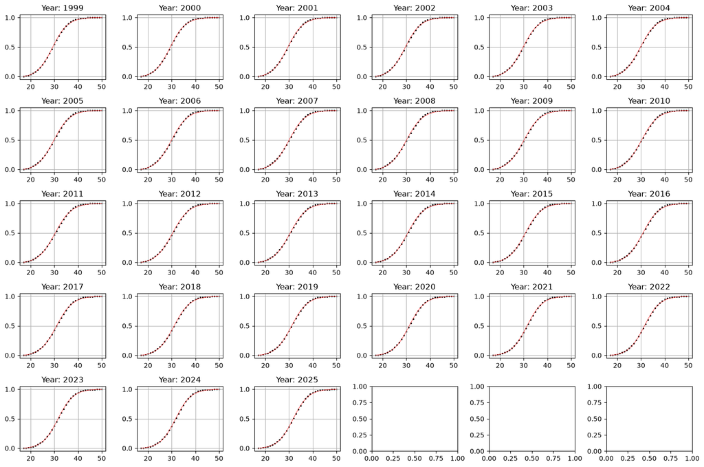

```python
# fit the sigmoids and extrapolate for next years
from scipy.optimize import curve_fit

def constrained_sigmoid(x: float, x0: float, k: float) -> float:
    """
    Compute a constrained sigmoid function that is 0 at the start and 1 at the end.

    Parameters:
    x (float): The input value.
    x0 (float): The x-value of the sigmoid's midpoint.
    k (float): The steepness of the curve.

    Returns:
    float: The output of the constrained sigmoid function.
    """
    y = 1 / (1 + np.exp(-k * (x - x0)))
    y = y - y[0]
    y = y / y[-1]
    return y

def fit_sigmoid(x, y):
    p0 = [np.mean(x), 0.3]
    popt, pcov = curve_fit(constrained_sigmoid, x, y, p0, bounds=([18, 0.01], [50, 2]))
    return popt

fig, axs = plt.subplots(5,6, figsize=[15, 10])
coeff_by_year = {} # {year: [x0, k]}
for iplot, year in enumerate(fert_by_age_cum.columns):
    x = fert_by_age_cum.index
    y = fert_by_age_cum.loc[:, year]
    coeff_by_year[year] = fit_sigmoid(x, y)
    y_fit = constrained_sigmoid(x, *coeff_by_year[year])
    ax = axs.flatten()[iplot]
    ax.scatter(x, y, color="black", marker="o", s=2)
    ax.set_title(f"Year: {year}")
    ax.plot(x,y_fit, color="red", lw=0.5)
    ax.grid()
plt.tight_layout()
plt.show()
```

```python
df_coeff = pd.DataFrame(coeff_by_year).T
df_coeff.columns = ["x0", "k"]
fig = make_subplots(rows=1, cols=2).update_layout(
    width=1000,
    title="Sigmoid parameters over time: x0 (center) an k (steepness)"
)
fig.add_trace(go.Scatter(x=df_coeff.index, y=df_coeff["x0"], mode="markers", name="x0"),row=1, col=1)
fig.add_trace(go.Scatter(x=df_coeff.index, y=df_coeff["k"], mode="markers", name="k"), row=1, col=2)

# I will keep x0 linear and k constant to have just one parameter to control (x0, which is average age of fertility)
x0_coeff = np.polyfit(df_coeff.index, df_coeff["x0"], 1)
k = df_coeff["k"].mean()
fig.add_trace(go.Scatter(x=df_coeff.index, y=np.polyval(x0_coeff, df_coeff.index), mode="lines", name="x0 linear fit"), row=1, col=1)
fig.add_trace(go.Scatter(x=df_coeff.index, y=[k]*df_coeff.index.size, mode="lines", name="k mean"), row=1, col=2)
fig.show()
print("x0_coeff", x0_coeff)
print("k", k)
```

[interactive chart not shown]

```
x0_coeff [ 9.61714369e-02 -1.63088348e+02]
k 0.2963913700353926
```

Visually, it looks ok to model the cumulative sum of fertility over mothers' age like this: a sigmoid, function of `x0` and `k`, where:

- `x0` is a linear function of the year of observation (i.e., motherhood age is shifing ahead with years)
- `k` is the steepness of the sigmoid, it is going up and down, but there is not a significant error if I keep it constant (otherwise I should guess whether to fit it with a parabola or a sinusoid!)

Now that I know the disribution of the fertility rate, I can distribute the number of new borns accordingly.

```python
total_newborns_by_year = dfp.iloc[0,:].shift(-1).dropna().to_dict() # newborns @ year of observation (shifting by -1 year beacause if there is a <1 year old on January 1st, he was born in the previous year)

fertiliy_by_year = {}
for year, tot_nb in total_newborns_by_year.items():
    women = dfp.loc[17:50, year]/2 # assuming half of the population are women, which is reasonable globally but may not be the case for each age group 18-50
    x0 = np.polyval(x0_coeff, year)
    sigmoid = constrained_sigmoid(women.index, x0, k)
    distrib = np.diff(sigmoid) # turning the sigmoid to a normaized distribution from 18 to 50
    mothers = sum(distrib * women.values[1:])
    fertiliy_by_year[year] = tot_nb / mothers

# REMEMBER: the fertility_by_year I computed here will be very similar to the official one by ISTAT,
# but slightly different because there may be diffences in the calculations (e.g., exact age of the mothers, infancy mortality, etc.).
# However, it is consistent to generate the correct number of newborns.
```

## Store and recover data

```python
# Store the coefficients
fertility_json = {
    "last_observed_year": max(fertiliy_by_year.keys()),
    "last_observed_value": fertiliy_by_year[max(fertiliy_by_year.keys())],
    "sigmoid_x0": list(x0_coeff),
    "sigmoid_k": k,
    "assumed_women_ratio": 0.5,
    "last_official_year": int(df6.query("CITIZENSHIP == 'TOTAL'").TIME_PERIOD.max()),
    "last_official_value": float(df6.query("CITIZENSHIP == 'TOTAL'").sort_values("TIME_PERIOD").iloc[-1].value),
    "calibration": "Effective rate reproducing age-0 residents on next 1 January; not the official TFR"
}
with open("../data/fertility_fitted.json", "w") as f:
    json.dump(fertility_json, f, indent=4)
```

```python
# make a function that recovers the data and gives the nexborns from the population
fdata = json.load(open("../data/fertility_fitted.json"))
print("Fertility coefficients:")
display(fdata)

def get_newborns_next_year(dfp, year, fertility_rate, fdata):
    """Fom population and fertility rate for a given year,
    get the number of newborns for the NEXT year (fist January of year+1).
    """
    def constrained_sigmoid(x0, k):
        """Get sigmoid function, which is a cumsum of a distribution."""
        x = np.arange(17, 50+1)
        y = 1 / (1 + np.exp(-k * (x - x0)))
        y = y - y[0]
        y = y / y[-1]
        return y
    pop = dfp[year]
    mothers_potential = pop.loc[18:50].to_numpy() * fdata["assumed_women_ratio"]
    x0 = np.polyval(fdata["sigmoid_x0"], year)
    distrib = np.diff(constrained_sigmoid(x0, fdata["sigmoid_k"]))
    newborns = sum(mothers_potential * distrib) * fertility_rate
    return int(newborns)

get_newborns_next_year(dfp=dfp, year=2013, fertility_rate=1, fdata=fdata)
```

```
Fertility coefficients:
```

```
{'last_observed_year': 2025,
 'last_observed_value': 1.109729190221021,
 'sigmoid_x0': [0.09617143688493088, -163.08834799890786],
 'sigmoid_k': 0.2963913700353926,
 'assumed_women_ratio': 0.5,
 'last_official_year': 2025,
 'last_official_value': 1.14,
 'calibration': 'Effective rate reproducing age-0 residents on next 1 January; not the official TFR'}
```

```
375463
```

## Make plots compared to official data

```python
# Cached historical comparison; ISTAT observations take precedence for the current year.
ss_wb_fr = worldbank_fertility()
ss_wb_fr
```

```
year
1960    2.40
1961    2.44
1962    2.46
1963    2.51
1964    2.66
        ...
2020    1.24
2021    1.25
2022    1.24
2023    1.21
2024    1.18
Name: value, Length: 65, dtype: float64
```

```python
# compare all the fertility rates

fig = go.Figure().add_trace(go.Scatter(
        x=df6.query("CITIZENSHIP == 'TOTAL'").TIME_PERIOD,
        y=df6.query("CITIZENSHIP == 'TOTAL'").value,
        mode="lines",
        name="From ISTAT 'TOTAL'",
)).add_trace(go.Scatter(
        x=fert_by_age.columns.astype(int),
        y=fert_by_age.sum(axis=0)/1000,
        mode="lines",
        name="From ISTAT age-by-age summed",
)).add_trace(go.Scatter(
        x=ss_wb_fr.index,
        y=ss_wb_fr.values,
        mode="lines",
        name="From World Bank",
)).add_trace(go.Scatter(
        x=list(fertiliy_by_year.keys()),
        y=list(fertiliy_by_year.values()),
        mode="lines",
        name="From calculations",
)).update_layout(
    width=1000,
    title="Comparison of Fertility Rates from different sources and calculations",
    xaxis_title="Year",
    yaxis_title="Fertility Rate"
)

fig.show()
```

[interactive chart not shown]

Note that there is still some discrepancy between the fertility rate I compute and the ISTAT one, that may be due to:

- approximating exactly 50% of the population as women
- approximation in the sigmoid model shape with no mothers below 18 and above 50 years old
- the indirect way I'm computing the `mothers` from a distribution fitted on fertility rate

```python
# Official demographic-indicator projections, current release (see source manifest).
df3 = istat_data(
    resource_id="165_889_DF_DCIS_PREVDEM1_3", key={"REF_AREA": "IT", "DATA_TYPE": "TFR"}
).astype({"TIME_PERIOD": int})
print(f"ISTAT projection base: 1 January {df3.TIME_PERIOD.min()}")
df3
```

```
ISTAT projection base: 1 January 2025
```

|  | FREQ | REF_AREA | DATA_TYPE | FORECAST_INTERVAL | AGE | SEX | TIME_PERIOD | value |
| --- | --- | --- | --- | --- | --- | --- | --- | --- |
| 0 | A | IT | TFR | PROJLOW50 | TOTAL | 9 | 2025 | 1.14 |
| 1 | A | IT | TFR | PROJLOW50 | TOTAL | 9 | 2026 | 1.14 |
| 2 | A | IT | TFR | PROJLOW50 | TOTAL | 9 | 2027 | 1.14 |
| 3 | A | IT | TFR | PROJLOW50 | TOTAL | 9 | 2028 | 1.14 |
| 4 | A | IT | TFR | PROJLOW50 | TOTAL | 9 | 2029 | 1.13 |
| ... | ... | ... | ... | ... | ... | ... | ... | ... |
| 387 | A | IT | TFR | PROJUPP90 | TOTAL | 9 | 2076 | 1.63 |
| 388 | A | IT | TFR | PROJUPP90 | TOTAL | 9 | 2077 | 1.64 |
| 389 | A | IT | TFR | PROJUPP90 | TOTAL | 9 | 2078 | 1.65 |
| 390 | A | IT | TFR | PROJUPP90 | TOTAL | 9 | 2079 | 1.66 |
| 391 | A | IT | TFR | PROJUPP90 | TOTAL | 9 | 2080 | 1.66 |

392 rows × 8 columns

```python
# pivot data to have year, and OBS_VALUE of  INT_PREV="PROJMED" PROJLOW80 and PROJUPP80
df3p = df3.pivot(index="TIME_PERIOD", columns="FORECAST_INTERVAL", values="value")
df3p.head()
```

| FORECAST_INTERVAL TIME_PERIOD | PROJLOW50 | PROJLOW80 | PROJLOW90 | PROJMED | PROJUPP50 | PROJUPP80 | PROJUPP90 |
| --- | --- | --- | --- | --- | --- | --- | --- |
| 2025 | 1.14 | 1.13 | 1.13 | 1.14 | 1.14 | 1.15 | 1.15 |
| 2026 | 1.14 | 1.13 | 1.12 | 1.14 | 1.15 | 1.16 | 1.16 |
| 2027 | 1.14 | 1.13 | 1.12 | 1.15 | 1.16 | 1.17 | 1.18 |
| 2028 | 1.14 | 1.12 | 1.12 | 1.15 | 1.17 | 1.18 | 1.19 |
| 2029 | 1.13 | 1.12 | 1.11 | 1.15 | 1.17 | 1.19 | 1.20 |

```python
# plot the data with INT_PREV="PROJMED" as line and INT_PREV="PROJLOW80" and "PROJUP80" as area of the confidence interval
go.Figure(
    ).add_trace(go.Scatter(
        x=ss_wb_fr.index,
        y=ss_wb_fr.values,
        mode="lines",
        name="From World Bank",
    )
    ).add_trace(go.Scatter(
        x=df3p.index,
        y=df3p["PROJMED"],
        mode="lines",
        name="Projection",
        line=dict(color="black")
    )
    ).add_trace(go.Scatter(
        x=df3p.index,
        y=df3p["PROJLOW80"],
        mode="lines",
        name="Projection 80% confidence (lower bound)",
        fill=None,
        line=dict(color="gray"),  # Change color and make it more transparent
    )
    ).add_trace(go.Scatter(
        x=df3p.index,
        y=df3p["PROJUPP80"],
        mode="lines",
        name="Projection 80% confidence (upper bound)",
        fill="tonexty",
        line=dict(color="gray"),  # Change color and make it more transparent
    )
    ).update_layout(
        width=1000,
        title="Projection of Fertility Rate from ISTAT",
        xaxis_title="Year",
        yaxis_title="Fertility Rate",
    ).show()
```

[interactive chart not shown]

## Assuming 3 scenarios for future fertility rate

```python
last_year = max(fertiliy_by_year.keys())
end_year = 2100

fr_projections = {}
fr_projections['fertility: ↓ 0 in 2100'] = pd.Series(np.linspace(fertiliy_by_year[last_year], 0, end_year-last_year+1), index=range(last_year, end_year+1))
fr_projections['fertility: eq. to last'] = pd.Series([fertiliy_by_year[last_year]] * (end_year-last_year+1), index=range(last_year, end_year+1))
fr_projections['fertility: ↑ 2 in 2100'] = pd.Series(np.linspace(fertiliy_by_year[last_year], 2, end_year-last_year+1), index=range(last_year, end_year+1))

fig1 = deepcopy(fig)
for key, fr in fr_projections.items():
    fig1.add_trace(
        go.Scatter(
            x=fr.index, # Need to shift by one because they refer to "end of y" while I refer to "start of y+1" for the same quantity
            y=fr,
            name=f"SCENARIO - {key}",
            line=dict(dash="dot")
        )
    )

# add projection from ISTAT
fig1.add_trace(go.Scatter(
    x=df3p.index,
    y=df3p["PROJMED"],
    mode="lines", name=f"ISTAT base {df3p.index.min()} — central 80% interval", line=dict(color="black")))
fig1.add_trace(go.Scatter(
        x=df3p.index,
        y=df3p["PROJLOW80"],
        mode="lines", showlegend=False, fill=None,line=dict(color="gray")))
fig1.add_trace(go.Scatter(
        x=df3p.index,
        y=df3p["PROJUPP80"],
        mode="lines", showlegend=False, fill="tonexty",line=dict(color="gray")))

fig1.update_layout(
    title=None,
    xaxis_title="Year",
    legend_title="Data Source",
    margin=dict(l=0, r=0, t=20, b=0),
    width=780,
    height=280,
)
fig1.write_html("../images_output/fertility_scenarios.html")
last_istat_value = df6.query("CITIZENSHIP == 'TOTAL'").sort_values("TIME_PERIOD").iloc[-1]['value']
print(f"Fertilyty from last year ({last_year}) - my estimate: {fertiliy_by_year[last_year]:.2f}, ISTAT: {last_istat_value:.2f}")
print("Fertility rate future projection: 3 scenarios")
fig1.show()
```

```
Fertilyty from last year (2025) - my estimate: 1.11, ISTAT: 1.14
Fertility rate future projection: 3 scenarios
```

[interactive chart not shown]

## Conclusions

- The full-year ISTAT fertility observation is 1.14 children per woman in 2025 (release: 21 October 2026). The January–July 2026 estimate of 1.13 is provisional and is not a full-year model input.
- The age distribution and the model's effective fertility rate are refitted from the cached observations. The same fitted parameters now calibrate and generate births.
- The effective rate reproduces age-0 residents on the next 1 January under the 50% women assumption. It differs from the official TFR because it also absorbs sex composition, infant survival, migration and fitting approximations.
- The three scenarios start from this effective 2025 value; they are sensitivity assumptions, not probability intervals. The official comparison uses ISTAT's base-2025 projections through 2080, with its central 80% uncertainty interval.
- Future births still depend on the projected number of potential mothers and the extrapolated age profile.

Sources: [2025 fertility release](https://www.istat.it/en/press-release/births-and-fertility-of-the-resident-population-year-2026/), [base-2025 projections](https://www.istat.it/comunicato-stampa/previsioni-della-popolazione-residente-delle-famiglie-e-delle-forze-di-lavoro-base-1-1-2025/). Retrieval dates and filters are in `data/sources/*.json`.

← Home